# CORD-19 Text clustering

## Introduction

This script runs some simple clustering experiments on the CORD-19 corpus of documents related to the novel coronavirus COVID-19.

The code is adapted from here: https://eight2late.wordpress.com/2015/07/22/a-gentle-introduction-to-cluster-analysis-using-r/

## Reading in the corpus

I am assuming here that you have a plain-text form of the corpus. You can use the CORD-19-JSON-Parser.Rmd script to make plain-text forms of the corpus with your choice of paper sections, metadata, etc.

Set the following variables to get to your input and output directories.

```r
input.directory <- "/Users/transfer/Dropbox/Scripts-new/cord19output-titles"
input.directory <- "/Users/transfer/Dropbox/Scripts-new/cord19output-abstracts"
input.directory <- "/Users/transfer/Dropbox/Scripts-new/cord19output-papers"
output.directory <- "" # not currently used
input.file <- "" # not currently used
# set to TRUE for lots of helpful debugging output, or to FALSE to suppress same
DEBUG = TRUE
#DEBUG = FALSE
```

```r
#Create Corpus
docs <- Corpus(DirSource(input.directory))
docs.CRAFT <- Corpus(DirSource("/Users/transfer/Dropbox/a-m/Corpora/craft-2.0/articles/txt/"))

if (DEBUG) {
  #inspect a particular document
  writeLines(as.character(docs[[1]]))
  writeLines(as.character(docs.CRAFT[[1]]))
}
```

```
## Given the concerns about the increasing spread of 2019-nCoV, it is imperative that infection control and safety precautions be followed. Home stay is a fundamental safety step that can limit infections from spreading widely. But prolonged home stays can increase behaviors that lead to inactivity …
```

```r
# Create Document-Term Matrix
dtm <- DocumentTermMatrix(docs)
#print a summary
if (DEBUG) {
  dtm
}
```

```
## <<DocumentTermMatrix (documents: 154, terms: 4174)>>
## Non-/sparse entries: 8044/634752
## Sparsity           : 99%
## Maximal term length: 73
## Weighting          : term frequency (tf)
```

```r
dtm.CRAFT <- DocumentTermMatrix(docs.CRAFT)
```

From the web page where I got this code:

*We’ll need to do a few things before running the algorithm. Firstly, we need to convert the DTM into a standard matrix which can be used by dist, the distance computation function in R (the DTM is not stored as a standard matrix). We’ll also shorten the document names so that they display nicely in the graph that we will use to display results of hclust (the names I have given the documents are just way too long). Here’s the relevant code:*

```r
#convert dtm to matrix
m <- as.matrix(dtm)
#write as csv file (optional)
write.csv(m,file="dtmEight2Late.csv")
#shorten rownames for display purposes
# NEXT THREE LINES GIVE ME AN ERROR--CHECK COMMENTS ON WEB PAGE
#rownames(m) <- paste(substring(rownames(m),1,3),rep("..",nrow(m)),
#+                      substring(rownames(m), #nchar(rownames(m))-12,nchar(rownames(m))-4))

#compute distance between document vectors
rownames(m) <- substring(rownames(m), 1, 5) # assuming that row names are at least 5 characters long! Holds true of the file names in the CORD0-19 corpus.
d <- dist(m)

m.CRAFT <- as.matrix(dtm.CRAFT)
#write as csv file (optional)
write.csv(m.CRAFT,file="dtmEight2Late.csv")
#shorten rownames for display purposes
# NEXT THREE LINES GIVE ME AN ERROR--CHECK COMMENTS ON WEB PAGE
#rownames(m) <- paste(substring(rownames(m),1,3),rep("..",nrow(m)),
#+                      substring(rownames(m), #nchar(rownames(m))-12,nchar(rownames(m))-4))

#compute distance between document vectors
rownames(m.CRAFT) <- substring(rownames(m.CRAFT), 1, 5) # assuming that row names are at least 5 characters long! Holds true of the file names in the CORD0-19 corpus.
d <- dist(m.CRAFT)
```

#### Hierarchical clustering

From the web page where I got this code:

*Next we run hclust. The algorithm offers several options check out the documentation for details. I use a popular option called Ward’s method – there are others, and I suggest you experiment with them as each of them gives slightly different results making interpretation somewhat tricky (did I mention that clustering is as much an art as a science??). Finally, we visualise the results in a dendogram (see Figure 2 below).*

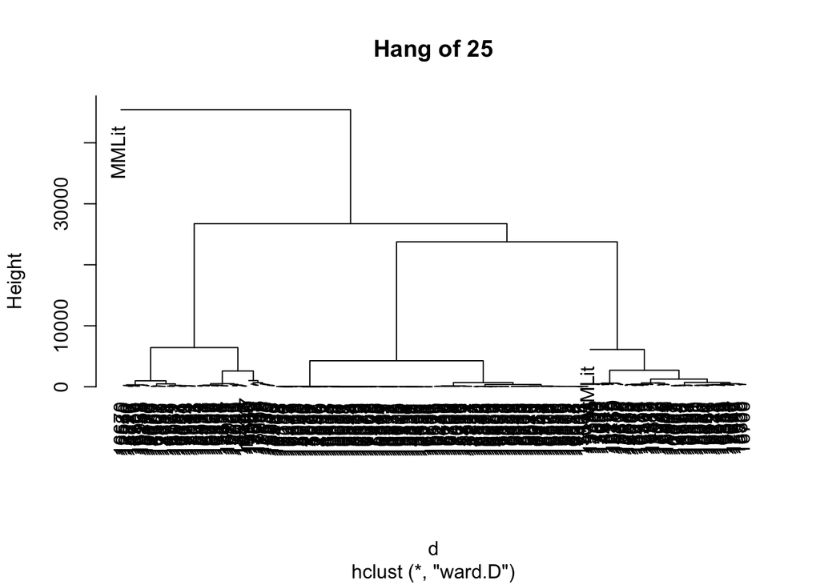

```r
#run hierarchical clustering using Ward’s method
groups <- hclust(d,method="ward.D")
#plot dendogram, use hang to ensure that display is reasonably interpretable
plot(groups, hang=0, main = "Hang of 25") # trying 25
```

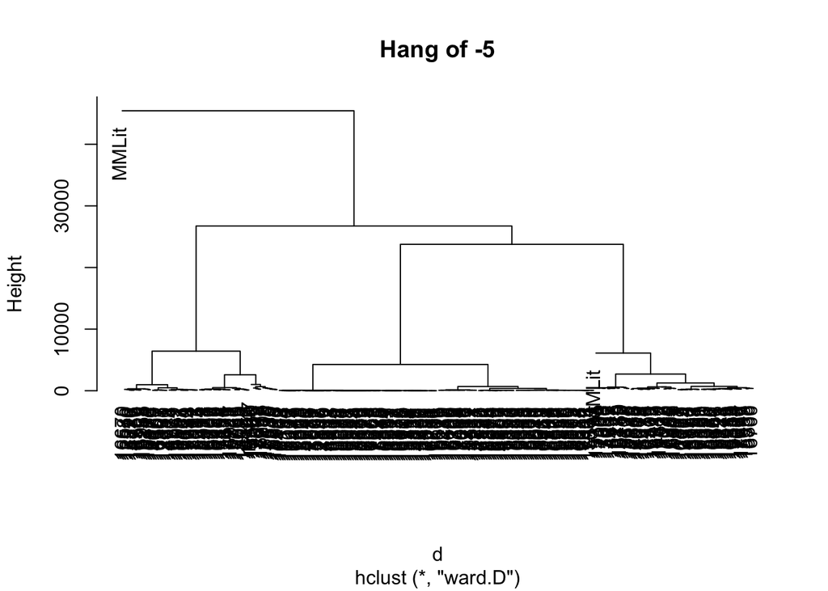

```r
plot(groups, hang=0, main = "Hang of -5") # trying -5
```

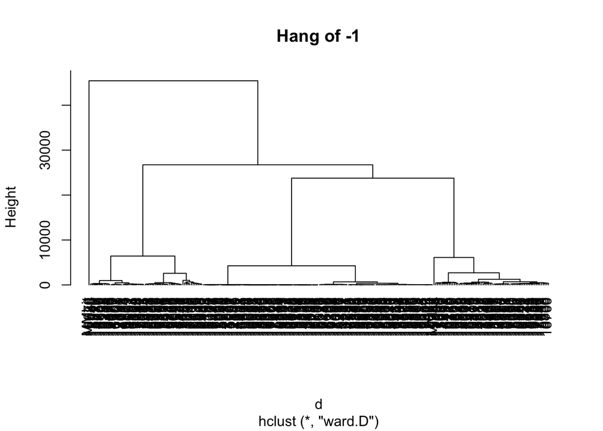

```r
plot(groups, hang=-1, main = "Hang of -1") # from the guy who wrote the code
```

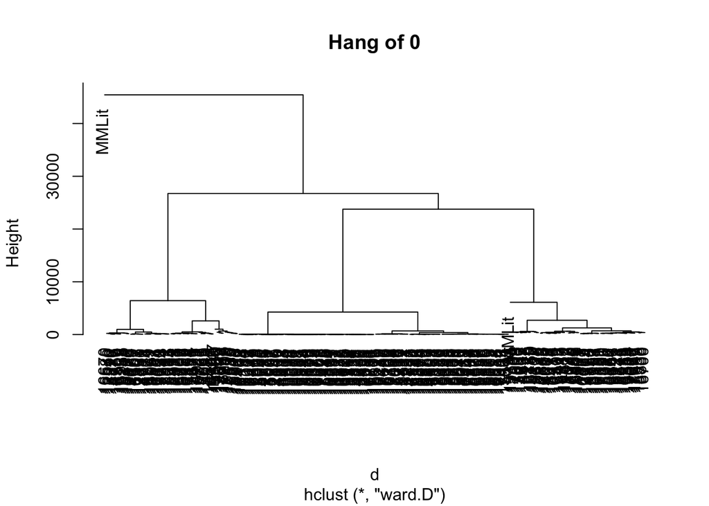

```r
plot(groups, hang=0, main = "Hang of 0") # trying 0
```

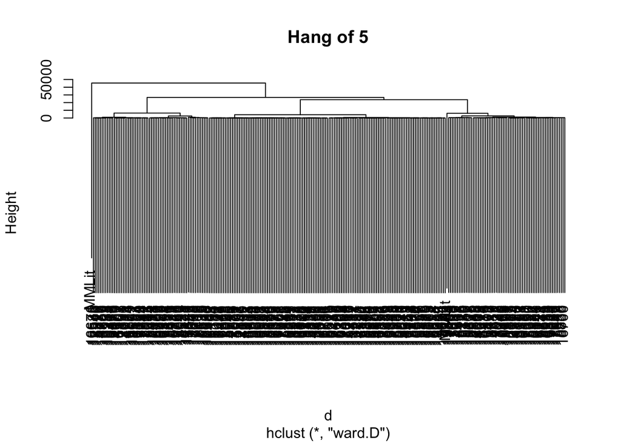

```r
plot(groups, hang=5, main = "Hang of 5") # trying 5
```

#### K-means clustering

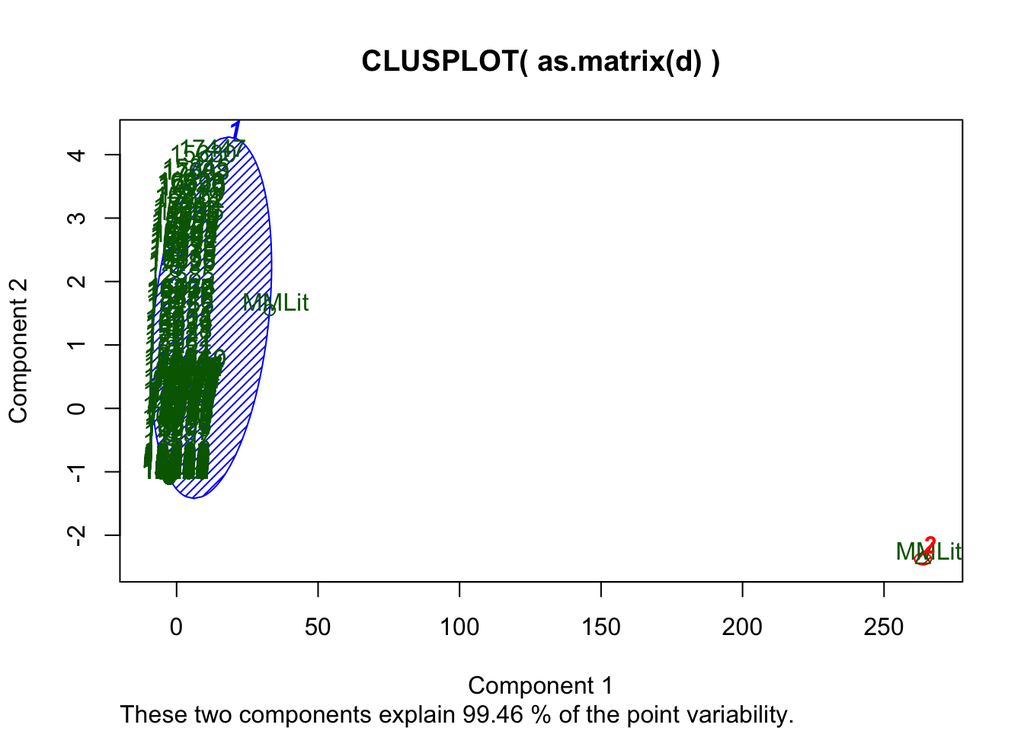

```r
#k means algorithm, 2 clusters, 100 starting configurations
kfit <- kmeans(d, 2, nstart=100)
#plot – need library cluster
library(cluster)
clusplot(as.matrix(d), kfit$cluster, color=T, shade=T, labels=2, lines=0)
```

#### Determining the optimal number of clusters

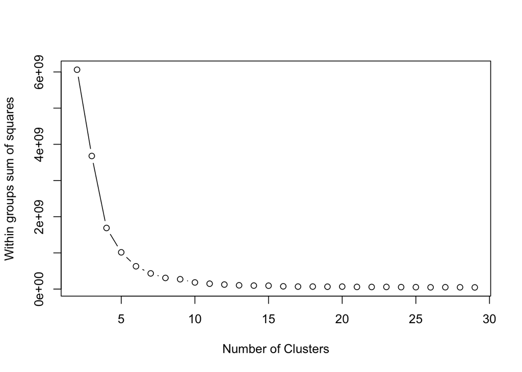

```r
#kmeans – determine the optimum number of clusters (elbow method)
#look for “elbow” in plot of summed intra-cluster distances (withinss) as fn of k
wss <- 2:29
for (i in 2:29) wss[i] <- sum(kmeans(d,centers=i,nstart=25)$withinss)
plot(2:29, wss[2:29], type="b", xlab="Number of Clusters",ylab="Within groups sum of squares")
```

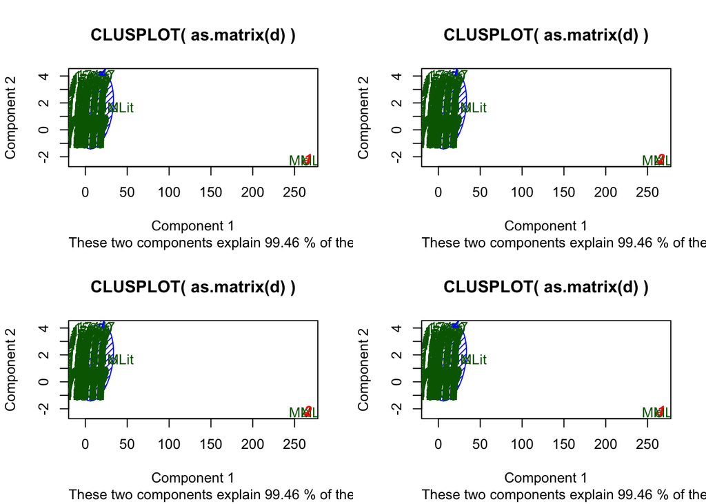

```r
library(cluster) # move this to set-up after development
default.parameters <- par()
par(mfrow=c(2,2))

for (i in 2:5) {
  kfit <- kmeans(d, 2, nstart=100)
  #plot – need library cluster
  clusplot(as.matrix(d), kfit$cluster, color=T, shade=T, labels=2, lines=0)
}
```

```r
par(default.parameters) # gives me a bunch of warnings
```

### Looking at the stability of k-means clustering results

First hypothesis: no effect of varying *nstart* across a range of values of *k*.

Wait, this is stupid–I’m looking at the differences of the sizes of the first two clusters, but that’s not even meaningful with k of more than 2.

```r
library(cluster) # move this to set-up after development
#default.parameters <- par()
#par(mfrow=c(2,2))

nstart.values <- c(25, 50, 75, 100)
cluster.size.differences <- c()
for (k.itself in 2:5) {
  for (i in 1:length(nstart.values)) {}
  kfit <- kmeans(d, k.itself, nstart=nstart.values[i])
  print(paste("Cluster sizes:", kfit$size))
  cluster.size.difference <- kfit$size[1] - kfit$size[2]
  cluster.size.differences <- c(cluster.size.differences, cluster.size.difference)
  #plot – need library cluster
  #clusplot(as.matrix(d), kfit$cluster, color=T, shade=T, labels=2, lines=0)
}

boxplot(cluster.size.differences, main = "Ignore this graph")
#par(default.parameters) # gives me a bunch of warnings
```

[output not shown]

OK, so, there are other things about the clustering fits that might actually be meaningful, so let’s look at some of those.

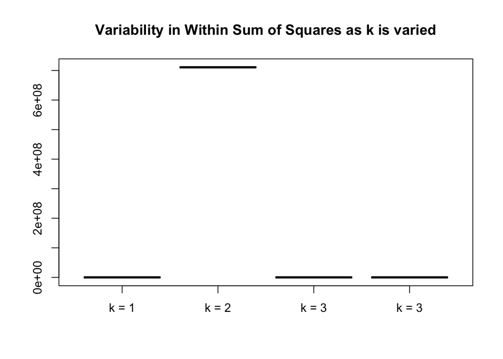

```r
library(cluster) # move this to set-up after development
#default.parameters <- par()
#par(mfrow=c(2,2))

nstart.values <- c(25, 50, 75, 100)
all.withinss <- c()
all.betweenss <- c()

by.k <- data.frame(k = as.character(), withinss = as.integer(), betweenss = as.integer())

#cluster.size.differences <- c()
for (k.itself in 2:5) {
  for (i in 1:length(nstart.values)) {}
  kfit <- kmeans(d, k.itself, nstart=nstart.values[i])
  #print(paste("Cluster sizes:", kfit$size))
  #cluster.size.difference <- kfit$size[1] - kfit$size[2]
  #cluster.size.differences <- c(cluster.size.differences, cluster.size.difference)
  #plot – need library cluster
  #clusplot(as.matrix(d), kfit$cluster, color=T, shade=T, labels=2, lines=0)
  all.withinss <- c(all.withinss, kfit$withinss)
  all.betweenss <- c(all.betweenss, kfit$betweenss)

  by.k <- rbind(by.k, c(k.itself, kfit$withinss, kfit$betweenss))
}

#boxplot(cluster.size.differences, main = "Ignore this graph")
#par(default.parameters) # gives me a bunch of warnings

boxplot(by.k[1,2], by.k[2,2], by.k[3,2], by.k[4,2], names = c("k = 1", "k = 2", "k = 3", "k = 3"),
        main = "Variability in Within Sum of Squares as k is varied")
```

```r
# scale is so large that you can't see whether there's any variability, or not. Normalize within_ss?

by.k
```

```
##   X2        X0 X6061661482.2072 X137342951407.634
## 1  2         0       6061661482      137342951408
## 2  3 710836367                0        2967134484
## 3  4         0        347560573                 0
## 4  5         0        242413874         234985697
```

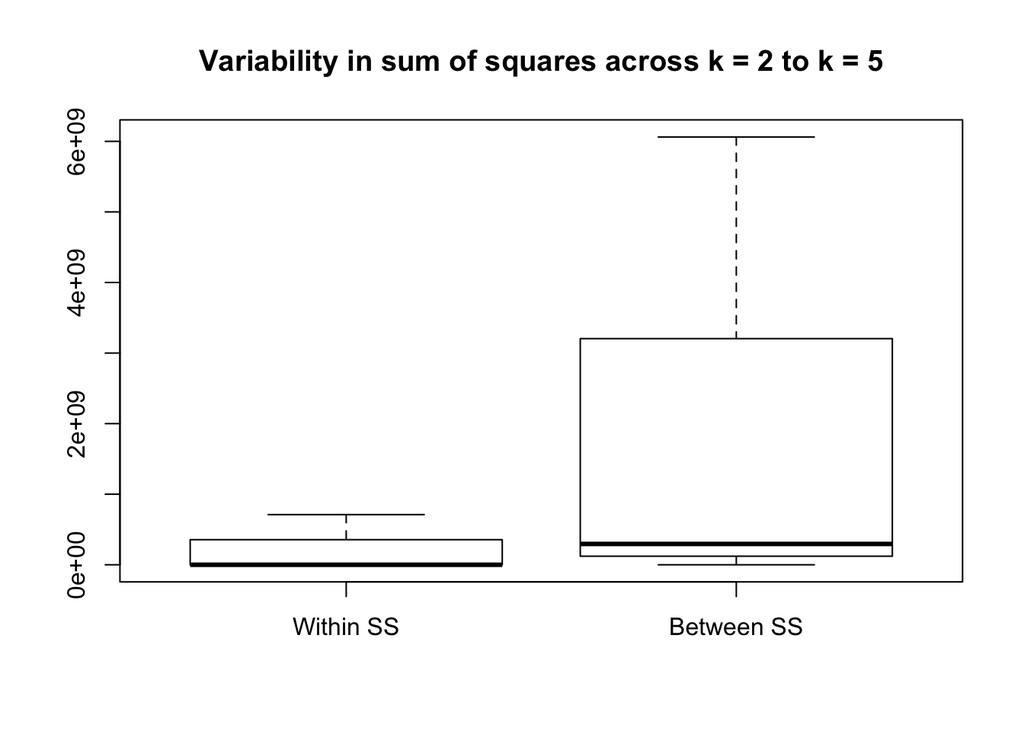

```r
boxplot(by.k[,2], by.k[,3],
        main = "Variability in sum of squares across k = 2 to k = 5",
        names = c("Within SS", "Between SS"))
```

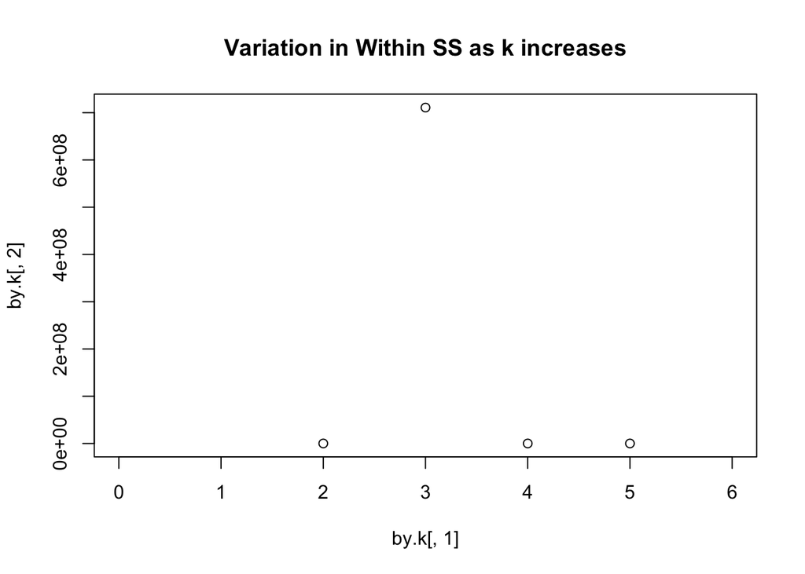

```r
plot(by.k[,1], by.k[,2], xlim = c(0,6),
     main = "Variation in Within SS as k increases")
```

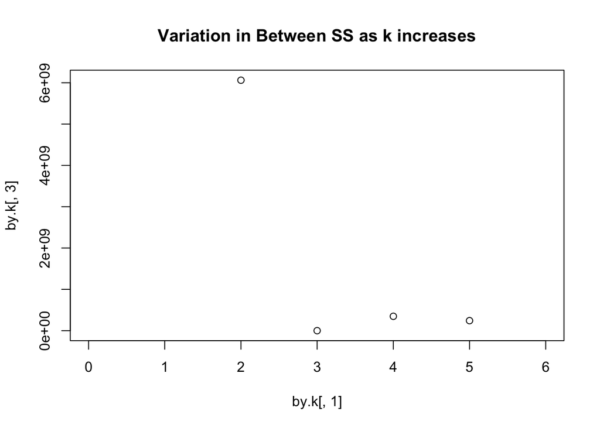

```r
plot(by.k[,1], by.k[,3], xlim = c(0,6),
     main = "Variation in Between SS as k increases")
```